# MultipleHypothesisTesting

Manpreet S. Katari

# Muliple hypothesis testing

We will confirm that we are likely to get more false postivies than expected if we repeat the the test many times.

## 1) Create random values for a gene

Our gene here has 5 control values and 5 treatment values. The values will be obtained from the same distribution so technically there should be a very small chance of getting genes with a low p-value.

```r
expgroup = rep(c("c","t"), each=5)

gene_exp = rnorm(10)

temp_ttest = t.test(gene_exp ~ expgroup, var.equal=T)
temp_ttest[["p.value"]]
```

```
## [1] 0.3348948
```

```r
temp_ttest$p.value
```

```
## [1] 0.3348948
```

Let’s generate the same values 20,000 times representing 20,000 genes.

```r
expvalues = matrix(NA, nrow=20000, ncol=10)

for ( i in 1:20000) {
  gene_exp = rnorm(10)
  expvalues[i,] = gene_exp
}
```

For each gene, do a t-test for each row

```r
exp_pvalues = numeric()
for ( i in 1:20000) {
  temp_ttest = t.test(expvalues[i,] ~ expgroup, var.equal=T)
  exp_pvalues[i] = temp_ttest[["p.value"]]  # result of the t-test
  #exp_pvalues[i] = temp_ttest$p.value  # result of the t-test

}
```

The p-value of random data has a uniform distribution. Which means the number of genes with p-value between 0 and 0.05 is the same as 0.95 and 1.

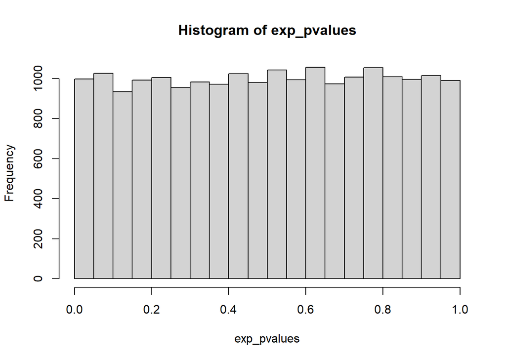

```r
hist(exp_pvalues)
```

```r
#
```

How many genes have a p-values less than 0.05?

```r
sum(exp_pvalues < 0.05)
```

```
## [1] 998
```

```r
#length(which(expvalues < 0.05))
```

Since .05 * 20,000 = 1,000, we expect the number here to be around 1000. Which means, if your data is random, you should exect 1000 genes to show differential expression just by chance !!!

## Let’s pretend 3000 genes have a difference in expression.

Create new matrix where we change the mean of second group. Let’s make one group mean of 2 and the other mean of 8.

```r
newexpvalues = matrix(NA, nrow=20000, ncol=10)

for ( i in 1:3000) {
  gene_exp = rnorm(5, mean = 2)
  newgene_exp = rnorm(5, mean = 8)
  newexpvalues[i,] = c(gene_exp, newgene_exp)
}

for ( i in 3001:20000) {
  gene_exp = rnorm(5, mean=2)
  newgene_exp = rnorm(5, mean=2)
  newexpvalues[i,] = c(gene_exp, newgene_exp)
}
```

```r
newexp_pvalues = numeric()
for ( i in 1:20000) {
  temp_ttest = t.test(newexpvalues[i,] ~ expgroup, var.equal=T)
  newexp_pvalues[i] = temp_ttest[["p.value"]]  # result of the t-test
  #exp_pvalues[i] = temp_ttest$p.value  # result of the t-test

}
```

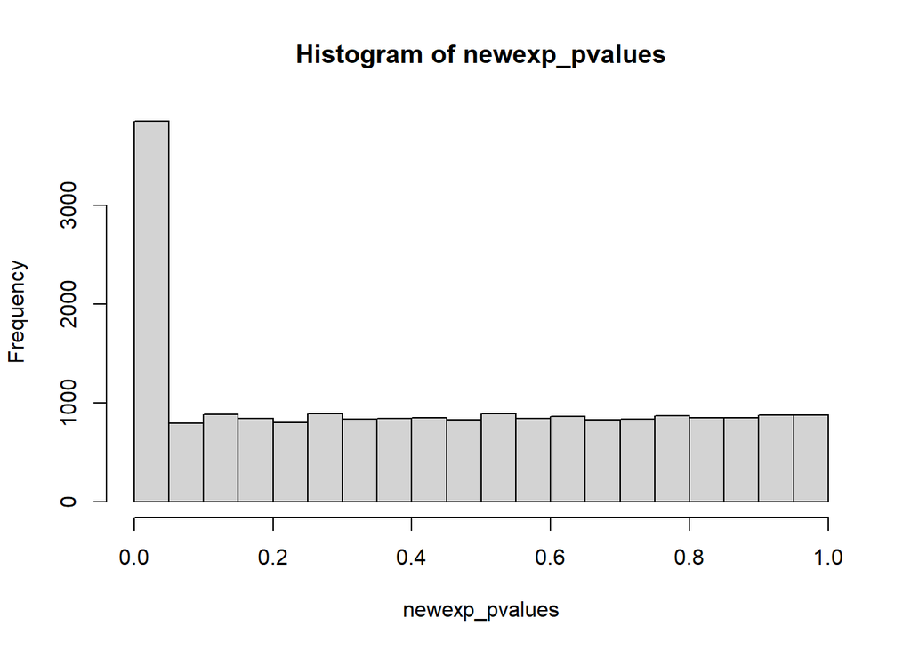

```r
hist(newexp_pvalues)
```

```r
#
```

P-value here is more skewed toward 0, so we expect more genes to be truly different.

```r
sum(newexp_pvalues < 0.05)
```

```
## [1] 3844
```

```r
#length(which(expvalues < 0.05))
```

Our false positive rate is the amount of our result we expect to be false.

```r
sum(exp_pvalues < 0.05)/sum(newexp_pvalues < 0.05)
```

```
## [1] 0.2596254
```

Adjust the p-values which corrects for false positive rate. Now the genes that pass this cutoff will have a 5% false positive rate.

```r
adjpvalue = p.adjust(newexp_pvalues, method="fdr")

sum(adjpvalue < 0.05)
```

```
## [1] 3128
```

# Benjamini Hochberg by hand

## First put all the p-values sorted.

```r
sorted_pvalues = sort(newexp_pvalues, decreasing = F)
head(sorted_pvalues)
```

```
## [1] 3.773866e-10 3.794020e-10 4.678261e-10 1.679783e-09 2.713969e-09
## [6] 3.427856e-09
```

```r
tail(sorted_pvalues)
```

```
## [1] 0.9993110 0.9996081 0.9996333 0.9996412 0.9997706 0.9999865
```

## i is their rank

```r
i = rank(sorted_pvalues)
```

## Compare p-value to the BH critical value

Compare the p-value to the critical value. When p-value becomes greater than the critical value, stop. All p-values less than the critical value is significant.

$i$ is the rank, $m$ is the total number of p-values and $Q$ is the fdr you want to use as your cutoff.

$$q = \frac{i}{m}Q$$

```r
sigvalues=numeric()
for ( j in i) {
  q = 0.05*j/length(i)
  if (sorted_pvalues[j] < q) {
    sigvalues[j]=sorted_pvalues[j]
  } else {
    break
  }
}

length(sigvalues)
```

```
## [1] 3128
```